*You are currently looking at **version 1.5** of this notebook. To download notebooks and datafiles, as well as get help on Jupyter notebooks in the Coursera platform, visit the [Jupyter Notebook FAQ](https://www.coursera.org/learn/python-data-analysis/resources/0dhYG) course resource.*

# Assignment 3 - More Pandas

This assignment requires more individual learning then the last one did - you are encouraged to check out the [pandas documentation](http://pandas.pydata.org/pandas-docs/stable/) to find functions or methods you might not have used yet, or ask questions on [Stack Overflow](http://stackoverflow.com/) and tag them as pandas and python related. And of course, the discussion forums are open for interaction with your peers and the course staff.

### Question 1 (20%)

Load the energy data from the file `Energy Indicators.xls`, which is a list of indicators of energy supply and renewable electricity production from the [United Nations](http://unstats.un.org/unsd/environment/excel_file_tables/2013/Energy%20Indicators.xls) for the year 2013, and should be put into a DataFrame with the variable name of **energy**.

Keep in mind that this is an Excel file, and not a comma separated values file. Also, make sure to exclude the footer and header information from the datafile. The first two columns are unneccessary, so you should get rid of them, and you should change the column labels so that the columns are:

`['Country', 'Energy Supply', 'Energy Supply per Capita', '% Renewable']`

Convert `Energy Supply` to gigajoules (there are 1,000,000 gigajoules in a petajoule). For all countries which have missing data (e.g. data with "...") make sure this is reflected as `np.NaN` values.

Rename the following list of countries (for use in later questions):

```
"Republic of Korea": "South Korea",
"United States of America": "United States",
"United Kingdom of Great Britain and Northern Ireland": "United Kingdom",
"China, Hong Kong Special Administrative Region": "Hong Kong"
```

There are also several countries with numbers and/or parenthesis in their name. Be sure to remove these,

e.g.

`'Bolivia (Plurinational State of)'` should be `'Bolivia'`,

`'Switzerland17'` should be `'Switzerland'`.

Next, load the GDP data from the file `world_bank.csv`, which is a csv containing countries' GDP from 1960 to 2015 from [World Bank](http://data.worldbank.org/indicator/NY.GDP.MKTP.CD). Call this DataFrame **GDP**.

Make sure to skip the header, and rename the following list of countries:

```
"Korea, Rep.": "South Korea",
"Iran, Islamic Rep.": "Iran",
"Hong Kong SAR, China": "Hong Kong"
```

Finally, load the [Sciamgo Journal and Country Rank data for Energy Engineering and Power Technology](http://www.scimagojr.com/countryrank.php?category=2102) from the file `scimagojr-3.xlsx`, which ranks countries based on their journal contributions in the aforementioned area. Call this DataFrame **ScimEn**.

Join the three datasets: GDP, Energy, and ScimEn into a new dataset (using the intersection of country names). Use only the last 10 years (2006-2015) of GDP data and only the top 15 countries by Scimagojr 'Rank' (Rank 1 through 15).

The index of this DataFrame should be the name of the country, and the columns should be ['Rank', 'Documents', 'Citable documents', 'Citations', 'Self-citations', 'Citations per document', 'H index', 'Energy Supply', 'Energy Supply per Capita', '% Renewable', '2006', '2007', '2008', '2009', '2010', '2011', '2012', '2013', '2014', '2015'].

*This function should return a DataFrame with 20 columns and 15 entries.*

**Note: integer parameter skip_footer in pandas.read_excel is the NUMBER of rows to skip at the end; it's NOT the row at which to start skipping rows**

```python
import copy
joinedDf = None

joinedOuter = None

#NOTE: global variables above have been introduced for the purposes of communicating with the answer_two() function

def answer_one():
    import pandas as pd
    import re
    col_names = ['Country', 'Energy Supply', 'Energy Supply per Capita', '% Renewable']
    energy = pd.read_excel('Energy Indicators.xls',skiprows = 17, skip_footer = 38, parse_cols = "C:G", names = col_names, na_values = '...')
    energy['Energy Supply']=10**6*energy['Energy Supply']
    energy['Country'].replace(r'[\d]','', inplace = True, regex = True) #replace  digits with empty space
    energy['Country'].replace(r'\([\S\s]*\)','', inplace = True, regex = True) #any parenthesized text (including the parentheses)
    #with the empty string; also handles nested parentheses (e.g 'Congo (The Democratic Republic (yes it's a republic))is awesome' -> 'Congo is awesome')
    energy_nameChangeMap = {"Republic of Korea": "South Korea", "United States of America": "United States", "United Kingdom of Great Britain and Northern Ireland": "United Kingdom",
               "China, Hong Kong Special Administrative Region": "Hong Kong" }

    #----CODE DOWN TO HERE READS 'Energy Indicators.xls', AND MAKES SOME CHANGES TO THE 'Energy Supply' COLUMN AS
    #WELL AS SOME PRELIMINARY CHANGES TO THE 'Country" COLUMN----------------------------------------------------


    #modify is a function that'll be used to change the Country field of both the energy and the gdp data frames
    def modify(e, d):
        if e in d.keys():
            return d[e]
        else:
            return e.strip()
    energy['Country'] = energy['Country'].apply(modify, args = (energy_nameChangeMap,)) #if function to apply to elements of
    #Pandas series takes more than one argument, pass the other arguments as a tuple bound to parameter name 'args'
    gdp = pd.read_csv('world_bank.csv', header = 4)
    gdp_nameChangeMap = {"Korea, Rep.": "South Korea", "Iran, Islamic Rep.": "Iran", "Hong Kong SAR, China": "Hong Kong"}
    gdp['Country Name'] = gdp['Country Name'].apply(modify, args = (gdp_nameChangeMap,))


    #----THE ABOVE CHUNK OF CODE READS 'world_bank.csv' AND MAKES CHANGES TO THE 'Country' field in both it
    #and in energy--------------------------------------------------------------------------------------------------
    ScimEn = pd.read_excel('scimagojr-3.xlsx')

    gdpColsToKeep = [gdp.columns[0]]+list(gdp.columns[-10:])
    gdpToKeep = gdp.loc[:,gdpColsToKeep]
    gdpToKeep.rename(columns = {'Country Name':'Country'}, inplace = True)
    #ScimEn_tokeep = ScimEn.sort_values(by = 'Rank').query('Rank<=15')
    joined = ScimEn.merge(energy, on = 'Country', how = 'inner').merge(gdpToKeep, on = 'Country', how = 'inner').set_index('Country')

    global joinedDf
    joinedDf = copy.deepcopy(joined)

    global joinedOuter
    joinedOuter = ScimEn.merge(energy, on = 'Country', how ='outer').merge(gdpToKeep, on = 'Country', how = 'outer').set_index('Country')

    filtered = joined.query('Rank<=15')
    #---THIS FINAL CHUNK OF CODE (ABOVE) READS IN DATA FROM 'scimagojr-3.xlsx' into ScimEn, REMOVES COLUMNS FROM gdp and assigns to gdpToKeep,
    #filters the relevant observations from ScimEn into ScimEn_tokeep, and performs the 3-way merge btwn ScimEn_tokeep,
    # energy and gdpToKeep on the Country field
    return filtered

#answer_one()
```

### Question 2 (6.6%)

The previous question joined three datasets then reduced this to just the top 15 entries. When you joined the datasets, but before you reduced this to the top 15 items, how many entries did you lose?

```python
%%HTML
<svg width="800" height="300">
  <circle cx="150" cy="180" r="80" fill-opacity="0.2" stroke="black" stroke-width="2" fill="blue" />
  <circle cx="200" cy="100" r="80" fill-opacity="0.2" stroke="black" stroke-width="2" fill="red" />
  <circle cx="100" cy="100" r="80" fill-opacity="0.2" stroke="black" stroke-width="2" fill="green" />
  <line x1="150" y1="125" x2="300" y2="150" stroke="black" stroke-width="2" fill="black" stroke-dasharray="5,3"/>
  <text  x="300" y="165" font-family="Verdana" font-size="35">Everything but this!</text>
</svg>
```

```python
def answer_two():
    answer_one()
    return joinedOuter.shape[0] - joinedDf.shape[0]

#Note: what the question is explicitly asking is not quite what the autograder checks for.
#answer_two()
```

```
156
```

Answer the following questions in the context of only the top 15 countries by Scimagojr Rank (aka the DataFrame returned by `answer_one()`)

### Question 3 (6.6%)

What is the average GDP over the last 10 years for each country? (exclude missing values from this calculation.)

*This function should return a Series named `avgGDP` with 15 countries and their average GDP sorted in descending order.*

```python
def getGDP_top15():
    import pandas as pd
    import numpy as np
    Top15 = answer_one()
    def modify(e, d):
        if e in d.keys():
            return d[e]
        else:
            return e.strip()
    gdp = pd.read_csv('world_bank.csv', header = 4)
    gdp_nameChangeMap = {"Korea, Rep.": "South Korea", "Iran, Islamic Rep.": "Iran", "Hong Kong SAR, China": "Hong Kong"}
    gdp['Country Name'] = gdp['Country Name'].apply(modify, args = (gdp_nameChangeMap,))
    validCountries = Top15.index.tolist()
    return gdp.pipe(lambda x: x.loc[x['Country Name'].isin(validCountries)]).set_index('Country Name')

def getGDP_top15_only_2006_2015():
    return getGDP_top15().loc[:,[str(x) for x in range(2006,2016)]]

def answer_three():
    import pandas as pd
    import numpy as np
    Top15 = answer_one()
    def modify(e, d):
        if e in d.keys():
            return d[e]
        else:
            return e.strip()
    gdp = pd.read_csv('world_bank.csv', header = 4)
    gdp_nameChangeMap = {"Korea, Rep.": "South Korea", "Iran, Islamic Rep.": "Iran", "Hong Kong SAR, China": "Hong Kong"}
    gdp['Country Name'] = gdp['Country Name'].apply(modify, args = (gdp_nameChangeMap,))
    validCountries = Top15.index.tolist()
    return gdp.pipe(lambda x: x.loc[x['Country Name'].isin(validCountries)]).set_index('Country Name')\
    .loc[:,[str(x) for x in range(2006,2016)]].apply(np.mean, axis = 1). sort_values(ascending = False)

def answer_three_v2():
    import numpy as np
    return getGDP_top15_only_2006_2015().apply(np.mean, axis = 1). sort_values(ascending = False)

#answer_three_v2()
#NOTE: answer_three_v2() is an attempt to modularize the data processing
```

```
Country Name
United States         1.536434e+13
China                 6.348609e+12
Japan                 5.542208e+12
Germany               3.493025e+12
France                2.681725e+12
United Kingdom        2.487907e+12
Brazil                2.189794e+12
Italy                 2.120175e+12
India                 1.769297e+12
Canada                1.660647e+12
Russian Federation    1.565459e+12
Spain                 1.418078e+12
Australia             1.164043e+12
South Korea           1.106715e+12
Iran                  4.441558e+11
dtype: float64
```

### Question 4 (6.6%)

By how much had the GDP changed over the 10 year span for the country with the 6th largest average GDP?

*This function should return a single number.*

```python
def answer_four():
    country = answer_three_v2().index.tolist()[5]
    ofInterest = getGDP_top15_only_2006_2015().loc[country]
    return ofInterest[-1] - ofInterest[0]
```

### Question 5 (6.6%)

What is the mean `Energy Supply per Capita`?

*This function should return a single number.*

```python
def answer_five():
    import numpy as np
    Top15 = answer_one()
    return Top15.pipe(lambda x:x.loc[:,x.columns.str.endswith('Capita')]).iloc[:,0].mean()

#answer_five()
```

### Question 6 (6.6%)

What country has the maximum % Renewable and what is the percentage?

*This function should return a tuple with the name of the country and the percentage.*

```python
def answer_six():
    Top15 = answer_one()
    renewable_pct_col =  Top15.pipe(lambda x:x.loc[:,x.columns.str.contains('Renewable')]).iloc[:,0]
    return (renewable_pct_col.idxmax(), renewable_pct_col.max())
#answer_six()
```

```
('Brazil', 69.648030000000006)
```

### Question 7 (6.6%)

Create a new column that is the ratio of Self-Citations to Total Citations. What is the maximum value for this new column, and what country has the highest ratio?

*This function should return a tuple with the name of the country and the ratio.*

```python
top15_withCitationRatio = None
def answer_seven():
    import pandas as pd
    import copy
    Top15 = answer_one()
    Top15['selfCit_to_totCit'] = Top15['Self-citations']/Top15['Citations']
    columns = Top15.columns[:5].tolist()+[Top15.columns[-1]]+Top15.columns[5:-1].tolist()
    Top15 = Top15[columns]
    global top15_withCitationRatio
    top15_withCitationRatio = copy.deepcopy(Top15)
    selfCit_col= Top15.loc[:,Top15.columns.str.startswith('selfCit')].iloc[:,0]
    return (selfCit_col.idxmax(), selfCit_col.max())

#answer_seven()
```

### Question 8 (6.6%)

Create a column that estimates the population using Energy Supply and Energy Supply per capita. What is the third most populous country according to this estimate?

*This function should return a single string value.*

```python
def answer_eight():
    Top15 = answer_one()
    #print(Top15.columns.tolist())
    Top15['popEstimate'] = Top15['Energy Supply']/Top15['Energy Supply per Capita']
    currColumns = Top15.columns
    newColumns = currColumns[:9].tolist()+[currColumns[-1]]+currColumns[9:-1].tolist()
    Top15 = Top15[newColumns]
    return Top15['popEstimate'].nlargest(n=3).idxmin()


#answer_eight()
```

### Question 9 (6.6%)

Create a column that estimates the number of citable documents per person. What is the correlation between the number of citable documents per capita and the energy supply per capita? Use the `.corr()` method, (Pearson's correlation).

*This function should return a single number.*

*(Optional: Use the built-in function `plot9()` to visualize the relationship between Energy Supply per Capita vs. Citable docs per Capita)*

```python
def answer_nine():
    import pandas as pd
    Top15 = answer_one()
    Top15['popEstimate'] = Top15['Energy Supply']/Top15['Energy Supply per Capita']
    currColumns = Top15.columns
    newColumns = currColumns[:9].tolist()+[currColumns[-1]]+currColumns[9:-1].tolist()
    Top15 = Top15[newColumns]
    popEst = Top15['popEstimate']
    citableDocsPerCapita = Top15['Citable documents']/popEst
    energySupplyPerCapita = Top15['Energy Supply per Capita']
    return citableDocsPerCapita.corr(energySupplyPerCapita)

#answer_nine()
```

```
0.79400104354429435
```

```python
def plot9():
    import matplotlib as plt
    %matplotlib inline

    Top15 = answer_one()
    Top15['PopEst'] = Top15['Energy Supply'] / Top15['Energy Supply per Capita']
    Top15['Citable docs per Capita'] = Top15['Citable documents'] / Top15['PopEst']
    Top15.plot(x='Citable docs per Capita', y='Energy Supply per Capita', kind='scatter', xlim=[0, 0.0006])
```

```python
#plot9() # Be sure to comment out plot9() before submitting the assignment!
```

### Question 10 (6.6%)

Create a new column with a 1 if the country's % Renewable value is at or above the median for all countries in the top 15, and a 0 if the country's % Renewable value is below the median.

*This function should return a series named `HighRenew` whose index is the country name sorted in ascending order of rank.*

```python
def answer_ten():
    Top15 = answer_one()
    medVal = Top15['% Renewable'].median()
    #return Top15.columns.tolist()
    print(medVal)
    Top15['HighRenew']=Top15['% Renewable'].map(lambda x:1 if x>=medVal else 0)
    currCols = Top15.columns
    newCols = currCols[:5].tolist()+[currCols[9]]+[currCols[-1]]+currCols[5:9].tolist()+currCols[10:-1].tolist()
    Top15 = Top15[newCols]
    print(Top15)
    Top15.sort_values(by = 'Rank', inplace = True)
    return Top15['HighRenew']

#answer_ten()
```

### Question 11 (6.6%)

Use the following dictionary to group the Countries by Continent, then create a dateframe that displays the sample size (the number of countries in each continent bin), and the sum, mean, and std deviation for the estimated population of each country.

```
ContinentDict  = {'China':'Asia',
                  'United States':'North America',
                  'Japan':'Asia',
                  'United Kingdom':'Europe',
                  'Russian Federation':'Europe',
                  'Canada':'North America',
                  'Germany':'Europe',
                  'India':'Asia',
                  'France':'Europe',
                  'South Korea':'Asia',
                  'Italy':'Europe',
                  'Spain':'Europe',
                  'Iran':'Asia',
                  'Australia':'Australia',
                  'Brazil':'South America'}
```

*This function should return a DataFrame with index named Continent `['Asia', 'Australia', 'Europe', 'North America', 'South America']` and columns `['size', 'sum', 'mean', 'std']`*

```python
def answer_eleven():
    import numpy as np
    Top15 = answer_one()
    Top15['popEstimate'] = Top15['Energy Supply']/Top15['Energy Supply per Capita']
    ContinentDict  = {'China':'Asia',
                  'United States':'North America',
                  'Japan':'Asia',
                  'United Kingdom':'Europe',
                  'Russian Federation':'Europe',
                  'Canada':'North America',
                  'Germany':'Europe',
                  'India':'Asia',
                  'France':'Europe',
                  'South Korea':'Asia',
                  'Italy':'Europe',
                  'Spain':'Europe',
                  'Iran':'Asia',
                  'Australia':'Australia',
                  'Brazil':'South America'}
    return Top15.groupby(ContinentDict)['popEstimate'].agg({'size':'count', 'sum':'sum','mean':'mean', 'std':np.std}).assign(size = lambda x:float(x.size))
    #Note the size column (which really should be an integer, since it's the number of countries in that continent) is coerced
    #into a float for the purposes of circumventing the autograder warning
#answer_eleven().info()
```

```
<class 'pandas.core.frame.DataFrame'>
Index: 5 entries, Asia to South America
Data columns (total 4 columns):
mean    5 non-null float64
size    5 non-null float64
sum     5 non-null float64
std     3 non-null float64
dtypes: float64(4)
memory usage: 200.0+ bytes
```

### Question 12 (6.6%)

Cut % Renewable into 5 bins. Group Top15 by the Continent, as well as these new % Renewable bins. How many countries are in each of these groups?

*This function should return a **Series** with a MultiIndex of `Continent`, then the bins for `% Renewable`. Do not include groups with no countries.*

```python
def answer_twelve():
    import pandas as pd
    ContinentDict  = {'China':'Asia',
                  'United States':'North America',
                  'Japan':'Asia',
                  'United Kingdom':'Europe',
                  'Russian Federation':'Europe',
                  'Canada':'North America',
                  'Germany':'Europe',
                  'India':'Asia',
                  'France':'Europe',
                  'South Korea':'Asia',
                  'Italy':'Europe',
                  'Spain':'Europe',
                  'Iran':'Asia',
                  'Australia':'Australia',
                  'Brazil':'South America'}
    Top15 = answer_one()
    Top15['Renewable class'] = pd.cut(Top15['% Renewable'], 5)
    return Top15.groupby([ContinentDict,'Renewable class'])['Energy Supply'].count()

#answer_twelve()
```

### Question 13 (6.6%)

Convert the Population Estimate series to a string with thousands separator (using commas). Do not round the results.

e.g. 317615384.61538464 -> 317,615,384.61538464

*This function should return a Series `PopEst` whose index is the country name and whose values are the population estimate string.*

```python
def answer_thirteen():
    import locale
    Top15 = answer_one()
    Top15['PopEst'] = Top15['Energy Supply'] / Top15['Energy Supply per Capita']
    return Top15['PopEst'].map('{:,}'.format)

#type(answer_thirteen())
```

### Optional

Use the built in function `plot_optional()` to see an example visualization.

```python
def plot_optional():
    import matplotlib as plt
    %matplotlib inline


    Top15 = answer_one()
    ax = Top15.plot(x='Rank', y='% Renewable', kind='scatter',
                    c=['#e41a1c','#377eb8','#e41a1c','#4daf4a','#4daf4a','#377eb8','#4daf4a','#e41a1c',
                       '#4daf4a','#e41a1c','#4daf4a','#4daf4a','#e41a1c','#dede00','#ff7f00'],
                    xticks=range(1,16), s=6*Top15['2014']/10**10, alpha=.75, figsize=[16,6]);

    for i, txt in enumerate(Top15.index):
        ax.annotate(txt, [Top15['Rank'][i], Top15['% Renewable'][i]], ha='center')

    print("This is an example of a visualization that can be created to help understand the data. \
This is a bubble chart showing % Renewable vs. Rank. The size of the bubble corresponds to the countries' \
2014 GDP, and the color corresponds to the continent.")
```

```
This is an example of a visualization that can be created to help understand the data. This is a bubble chart showing % Renewable vs. Rank. The size of the bubble corresponds to the countries' 2014 GDP, and the color corresponds to the continent.
```

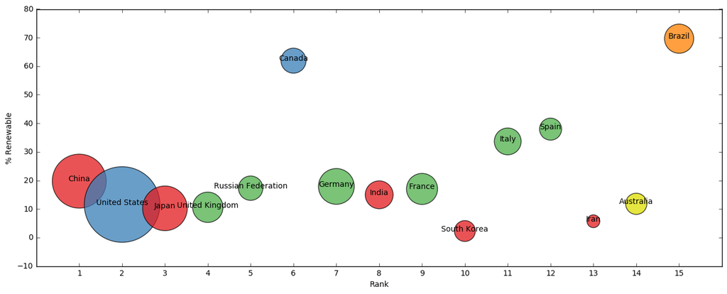

```python
#plot_optional() # Be sure to comment out plot_optional() before submitting the assignment!
```